# Exploring the role of process model parameters in phantom interactions on RTs

# Introduction

Phantom interactions are scale-dependent statistically significant noncrossover interactions between two or more factors that disappear after appropriate scale transformation.

**Key characteristics:**

- **Scale-Dependent:** The interaction’s presence or significance depends heavily on the scale used for the dependent variable.
- **Visual Cue:** On an interaction plot using the original scale, the lines representing the levels of one factor across the levels of another factor will be non-parallel but typically won’t cross within the observed data range (hence “noncrossover”). After transformation, these lines often become (approximately) parallel.
- **Removable:** The interaction can often be “removed” by changing the scale, potentially simplifying the model interpretation to only main effects on the transformed scale.

Phantom interactions are an artifact of the original dependent variable measurement scale. They can’t be used to conclude that the effect of one factor fundamentally changes depending on the level of another. As such, they highlight the importance of considering the appropriate scale for analyzing data, especially when effects might combine multiplicatively rather than purely additively.

# Test 1: Single participant tested over multiple days and conditions

```r
# Simulation design settings:
J <- 2    # Design factors
L <- 2    # Levels per factor
K <- J*L  # Conditions
D <- 8    # Repeated observations (experimental sessions)
N <- 120  # Trials per condition
```

We generate data for a single participant in a binary decision task with $K =$ 4 conditions defined by a simple 2-by-2 factorial design:

[output not shown]

For each condition $k$, we generate summary statistics for the choice and response time data using the EZ drift diffusion model (EZ-DDM). As such, the accuracy rate $\dot{A}_k$, mean response time $\dot{MRT}_k$, and response time variance $\dot{VRT}_k$ are modeled as:

$$\left\{\dot{A}_k, \dot{MRT}_k,
\dot{VRT}_k\right\} \sim \mbox{EZDDM}\left(\nu_{k}, \alpha_{k},
\tau\right )$$

where $\nu$, $\alpha$, and $\tau$ are the parameters of the simple drift diffusion model (the drift rate, boundary separation, and non-decision time, respectively).

We generate $D =$ 8 summary statistics per condition, as if the participant completed the task on $D$ experimental sessions.

## Simulate data

### Set true parameter values

We define arbitrary values for the boundary separation and drift rate parameters in each experimental condition such that **each parameter is only affected by a given main effect**.

```r
# Only Factor A has a main effect on the boundary separation
bound <- matrix(c(3,   5.5,
                  3.05, 5.55), nrow = L, ncol = L, byrow = TRUE)
# Only Factor B has a main effect on the drift rate
drift <- matrix(c(0.7, 0.75,
                  2.5, 2.45), nrow = L, ncol = L, byrow = TRUE)
```

As shown in the interaction plots below, the boundary separation parameter is only affected by Factor A, while the drift rate parameter is only affected by Factor B.

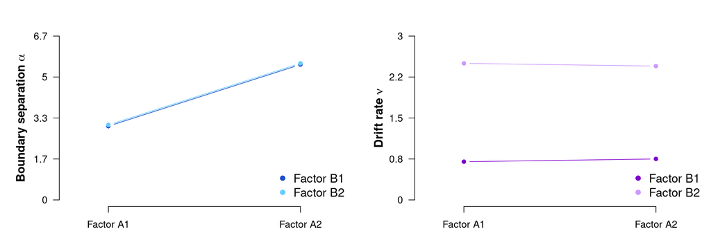

We prepare a list with the parameter values used to sample summary statistics for each experimental condition across experimental sessions.

```r
ddm_parameters <- list(
  bound = rep(as.vector(bound), D),  # Repeated over experimental sessions
  drift = rep(as.vector(drift), D),  # Repeated over experimental sessions
  nondt = rep(0.2, D*L*L)            # Same for all conditions and experimental sessions
)
```

So that the simulation design matrix ends up looking like this:

```
##   Drift Bound Nondt Factor.A Factor.B Condition Session
## 1  0.70  3.00   0.2       A1       B1         1       1
## 2  2.50  3.05   0.2       A1       B2         2       1
## 3  0.75  5.50   0.2       A2       B1         3       1
## 4  2.45  5.55   0.2       A2       B2         4       1
## 5  0.70  3.00   0.2       A1       B1         1       2
## 6  2.50  3.05   0.2       A1       B2         2       2
## 7  0.75  5.50   0.2       A2       B1         3       2
## 8  2.45  5.55   0.2       A2       B2         4       2
```

### Generate EZ summary statistics

We use our custom function `simSumStats()` to generate the EZ summary statistics for each experimental session:

```r
set.seed(seed)
sum_stats <- simSumStats(ddm_parameters, N)
```

```
##   Drift Bound Nondt Factor.A Factor.B Condition Session   A    Mrt    Vrt
## 1  0.70  3.00   0.2       A1       B1         1       1 109 1.9334 1.7990
## 2  2.50  3.05   0.2       A1       B2         2       1 120 0.7536 0.0957
## 3  0.75  5.50   0.2       A2       B1         3       1 119 3.8998 5.6490
## 4  2.45  5.55   0.2       A2       B2         4       1 120 1.3139 0.1880
## 5  0.70  3.00   0.2       A1       B1         1       2 101 1.7507 1.6247
## 6  2.50  3.05   0.2       A1       B2         2       2 120 0.8032 0.1140
## 7  0.75  5.50   0.2       A2       B1         3       2 118 3.5310 5.3093
## 8  2.45  5.55   0.2       A2       B2         4       2 120 1.3037 0.2258
```

## Noncrossover interaction in Mean RTs

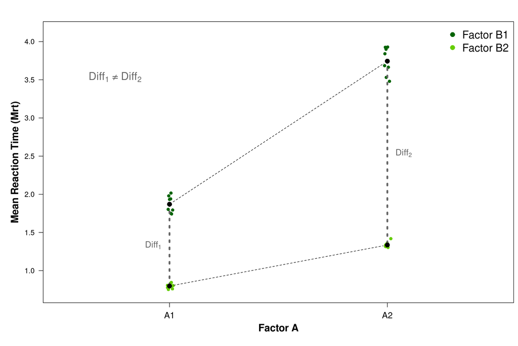

By running a frequentist ANOVA on the mean RTs generated and plotted above, we find that both Factor A and Factor B have significant main effect on the mean RTs, but more importantly, the interaction between the two factors is also statistically significant.

```r
# Run ANOVA test
anova_result <- aov(Mrt ~ Factor.A * Factor.B, data = full_data)
summary(anova_result)
```

```
##                   Df Sum Sq Mean Sq F value Pr(>F)
## Factor.A           1 11.637  11.637   998.4 <2e-16 ***
## Factor.B           1 24.221  24.221  2078.1 <2e-16 ***
## Factor.A:Factor.B  1  3.574   3.574   306.6 <2e-16 ***
## Residuals         28  0.326   0.012
## ---
## Signif. codes:  0 '***' 0.001 '**' 0.01 '*' 0.05 '.' 0.1 ' ' 1
```

These results are consistent with the Bayesian multiple regression model fit to the data below.

```r
modelFile <- here("output", "BUGS", "linear_model.bug")

model <- write("
model {
          # Priors
          beta0 ~ dnorm(0,1)        # Mean RT - Intercept/Baseline
          beta1 ~ dnorm(0,1)        # Factor A - Main effect
          beta2 ~ dnorm(0,1)        # Factor B - Main effect
          beta3 ~ dnorm(0,1)        # Factor A * Factor B - Interaction
          rt_lambda ~ dunif(0,3)    # Mean RT - Precision

          # Condition-specific Mean RT predictions
          for(j in 1:4){
              rt_pred[j] = beta0 + beta1*A[j]+beta2*B[j]+beta3*A[j]*B[j]
          }

          # Sampling model
          for (k in 1:length(meanRT)) {
              # Person-by-condition specificDM parameters
              meanRT[k]  ~ dnorm(rt_pred[cond[k]],rt_lambda)
            }
}", modelFile)
```

```
## module glm loaded
```

```
## [1] "No Rhat greater than 1.05"
```

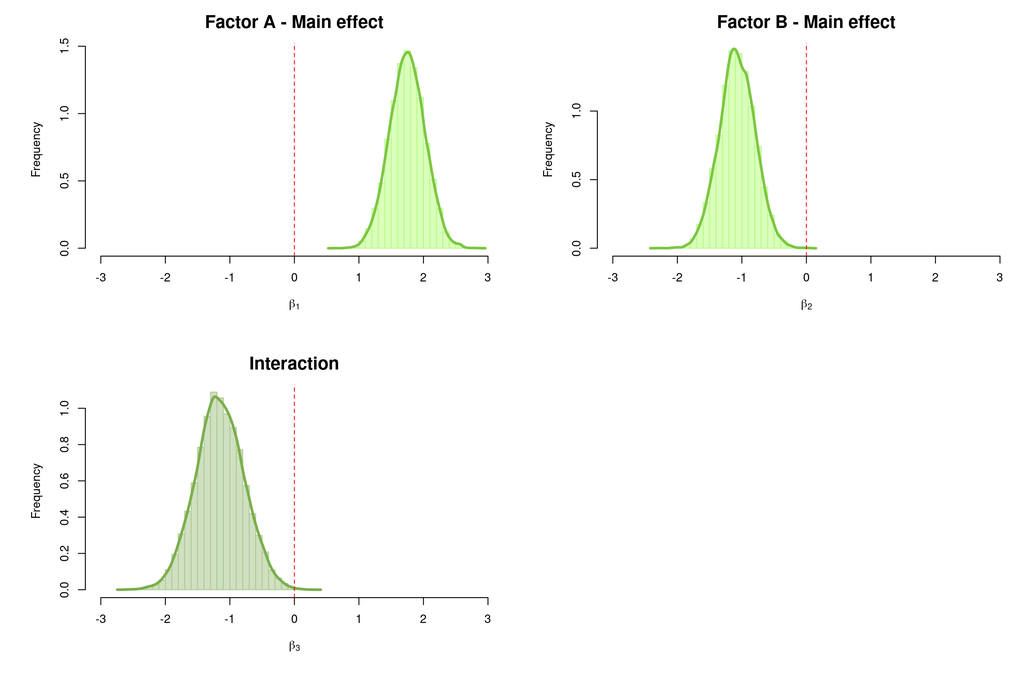

As shown in the plots above, all three posterior distributions for the regression coefficients have almost no posterior density at zero, indicating that the main and interaction effects of Factor A and Factor B on the mean RTs are supported by evidence.

## Fit a Bayesian EZ-DDM model

We now fit a Bayesian EZ-DDM model to the simulated data to properly quantify and evaluate the main and interaction effects of Factor A and Factor B on the boundary separation and drift rate parameters.

### JAGS model

We write a JAGS model that describes the drift rate and boundary separation parameters as a function of the levels of Factor A and Factor B, incorporating main effects and the interaction between them.

$$\begin{equation}
\nu_{k} = \mu_{\nu} + \gamma_{1}A_{k} + \gamma_{2}B_{k} +
\gamma_{3}A_{k}B_{k}\\
\end{equation}$$

$$\begin{equation}
\alpha_{k} = \mu_{\alpha} + \lambda_{1}A_{k} + \lambda_{2}B_{k} +
\lambda_{3}A_{k}B_{k}
\end{equation}$$

```r
modelFile <- here("output", "BUGS", "ezddm_model.bug")

model <- write("
model {
          ##################
          ####### Priors
          ##################
          drift_mu ~ dnorm(0,1)                      # Baseline drift rate
          drift_lambda ~ dgamma(2,1)
          drift_sigma = pow(drift_lambda, -0.5)
          bound_mu ~ dnorm(2,1)T(0,)                 # Baseline boundary separation
          bound_lambda ~ dgamma(2,1)
          bound_sigma = pow(bound_lambda, -0.5)
          nondt ~ dexp(1)                            # Participant-specific non-decision time

          # Regression coefficients (2 main effects + 1 interaction)
          for(i in 1:3){
              gamma[i] ~ dnorm(0,1)       # Drift rate regression coefficients
              lambda[i] ~ dnorm(0,1)      # Boundary separation regression coefficients
          }

          # Condition-specific drift rate and boundary separation
          for(j in 1:4){
              drift_pred[j] = drift_mu + gamma[1]*A[j]+gamma[2]*B[j]+gamma[3]*A[j]*B[j]
              bound_pred[j] = bound_mu + lambda[1]*A[j]+lambda[2]*B[j]+lambda[3]*A[j]*B[j]
          }

          #########################
          ####### Sampling model
          ####### (for each experimental session)
          #########################
          for (k in 1:length(meanRT)) {
              # Person-by-condition specificDM parameters
              drift[k] ~ dnorm(drift_pred[cond[k]],drift_lambda)
              bound[k] ~ dnorm(bound_pred[cond[k]],bound_lambda)

              # Forward equations from EZ Diffusion
              ey[k]  = exp(-bound[k] * drift[k])
              Pc[k]  = 1 / (1 + ey[k])
              PRT[k] = 2 * pow(drift[k], 3) / bound[k] * pow(ey[k] + 1, 2) / (2 * -bound[k] *
                      drift[k] * ey[k] - ey[k] * ey[k] + 1)
              MDT[k] = (bound[k] / (2 * drift[k])) * (1 - ey[k]) / (1 + ey[k])
              MRT[k] = MDT[k] + nondt

              # Sampling distributions for summary statistics
              correct[k] ~ dbin(Pc[k], nTrials[k])
              varRT[k]   ~ dnorm(1/PRT[k], 0.5*(nTrials[k]-1) * PRT[k] * PRT[k])
              meanRT[k]  ~ dnorm(MRT[k], PRT[k] * nTrials[k])
            }
}", modelFile)
```

### Run JAGS

```r
set.seed(seed)

# General setup
n.chains  <- 4;      n.iter    <- 3500
n.burnin  <- 250;    n.thin    <- 1

# Pass data to JAGS
data_toJAGS <- list("nTrials"  =  rep(N, length(full_data$Mrt)),
                    "meanRT"   =  full_data$Mrt,
                    "varRT"    =  full_data$Vrt,
                    "correct"  =  full_data$A,
                    "cond"     =  full_data$Condition,
                    "A"   =  ifelse(full_data$Factor.A == "A1", 0, 1),
                    "B"   =  ifelse(full_data$Factor.B == "B1", 0, 1))

# Specify parameters to keep track of
parameters <- c('gamma', 'lambda', 'drift', 'bound', 'drift_pred', 'bound_pred')

# Prepare initial values
myinits <- rep(list(list()), n.chains)
          for(i in 1:n.chains){
              myinits[[i]] <- list(drift = rnorm(length(data_toJAGS$nTrials),1,0.1))
          }

start <- Sys.time()
samples <- jags(data=data_toJAGS,
                parameters.to.save=parameters,
                model=modelFile,
                n.chains=n.chains,  n.iter=n.iter,
                n.burnin=n.burnin,  n.thin=n.thin,
                DIC=T, inits=myinits)
end <- Sys.time()

cat("Time taken:", round(difftime(end, start, units = "secs"), 2), "seconds")

# Extract posterior samples
gamma <- samples$BUGSoutput$sims.list$gamma   # Effects on the drift rate
lambda <- samples$BUGSoutput$sims.list$lambda # Effects on the boundary separation
# Predicted drift rates and boundary separations
drift_pred <- samples$BUGSoutput$sims.list$drift_pred
bound_pred <- samples$BUGSoutput$sims.list$bound_pred
```

### Convergence diagnostics

```r
rhats <- apply(samples$BUGSoutput$sims.array,3,getRhat)
rule <- 1.05
bad.Rhat <- which(rhats>rule)
if(length(bad.Rhat) > 0){
        which.are.bad.Rhats <- names(bad.Rhat)
        hist(rhats, breaks = 50)
        abline(v=rule, col="red", lty=2)
        legend("top",paste("Rhat > ",rule," | ",
                          (round(nrow(bad.Rhat)/(length(as.vector(rhats))),5))*100,
                          "% of chains | ", length(which.are.bad.Rhats), " chains", sep=""), lty=2, col="red", cex=0.4)
        table(which.are.bad.Rhats)
}else{      paste("No Rhat greater than ", rule, sep="")       }
```

```
## [1] "No Rhat greater than 1.05"
```

### Interaction plots

We plot the posterior distributions of the drift rate and boundary separation parameters for each experimental condition in the following interaction plots. We confirm that our model is able to recover the single-main effect structure of the true parameter values used to simulate the data.

[figure not shown]

### Effect sizes

Next, we look at the posterior distributions for the regression coefficients describing the main and interaction effects of Factor A and Factor B on the drift rate and boundary separation parameters. As expected, we find that Factor A only has a main effect on the boundary separation parameter, while Factor B only has a main effect on the drift rate parameter.

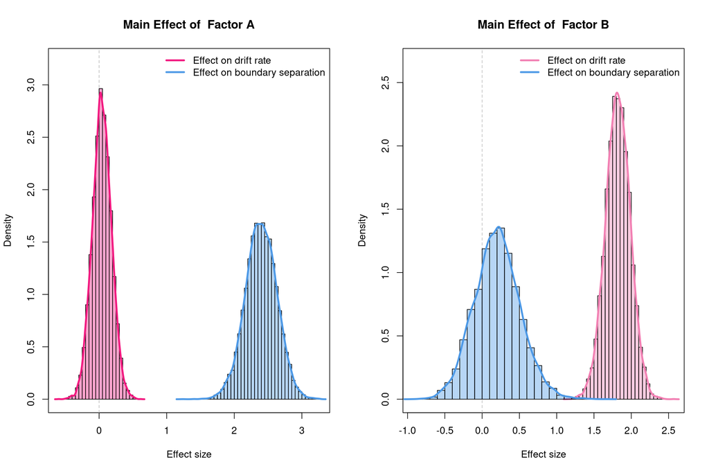

```
## The B.F. for gamma1 in favor of an effect is0.1574223. Evidence in favor of the null effect!
## The B.F. for gamma2 in favor of an effect isInf. Strong evidence in favor of the effect!
```

[figure not shown]